# Reproducible Research - Project 1

By Ervachon - April 2015

### 1 - Loading and preprocessing the data

Load the data (i.e. read.csv())

NB: the variable **ThePath** is the complete path where is the activity file.

```r
ActivityMonotoringData <- read.csv(paste(ThePath ,"activity.csv",sep =""))
```

Process/transform the data (if necessary) into a format suitable for your analysis Here i omit the NA value.

```r
ActivityMonotoringDataWithoutNA <- na.omit(ActivityMonotoringData)
```

### 2 - What is mean total number of steps taken per day?

Make a histogram of the total number of steps taken each day. NB: don’t forget to load the “plyr”" library.

```r
library(plyr)
NumberOfStepsByDay <- ddply(ActivityMonotoringDataWithoutNA,
                            .(ActivityMonotoringDataWithoutNA$date),
                            summarise, sum = sum(steps, na.rm = TRUE))
```

[figure not shown]

Calculate and report the mean and median total number of steps taken per day

```r
mean(NumberOfStepsByDay$sum)
```

```
## [1] 10766.19
```

```r
median(NumberOfStepsByDay$sum)
```

```
## [1] 10765
```

### 3 - What is the average daily activity pattern?

Make a time series plot (i.e. type = “l”) of the 5-minute interval (x-axis) and the average number of steps taken, averaged across all days (y-axis)

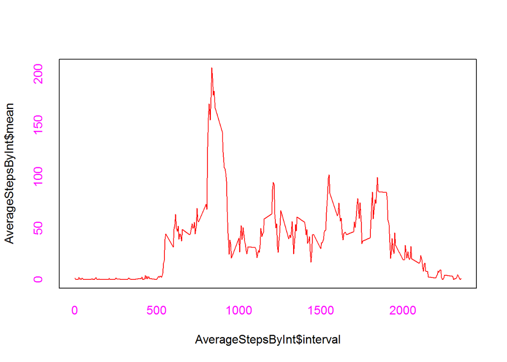

```r
AverageStepsByInt <- ddply(ActivityMonotoringDataWithoutNA, .(interval),
                            summarise, mean = mean(steps, na.rm = TRUE))
par(bg='white', fg='white', col='black', col.axis='magenta',
    col.lab='black', col.main='blue', col.sub='black')
plot ( AverageStepsByInt$interval, AverageStepsByInt$mean, type = "l", col = "red", bg.col = "blue")
```

Which 5-minute interval, on average across all the days in the dataset, contains the maximum number of steps?

```r
AverageStepsByInt[ AverageStepsByInt$mean == max(AverageStepsByInt$mean), ]
```

```
##     interval     mean
## 104      835 206.1698
```

### 4 - Imputing missing values

Calculate and report the total number of missing values in the dataset (i.e. the total number of rows with NAs)

```r
sum(is.na(ActivityMonotoringData$steps))
```

```
## [1] 2304
```

Devise a strategy for filling in all of the missing values in the dataset. The strategy does not need to be sophisticated, create a new dataset that is equal to the original dataset but with the missing data filled in.

Here I choose to replace NA values with the mean and make a new matrice.

```r
ActivityMonotoringData2 <- ActivityMonotoringData
ActivityMonotoringData2$steps[is.na(ActivityMonotoringData$steps)] <-
   AverageStepsByInt[AverageStepsByInt$interval ==
                        ActivityMonotoringData2$interval , ]$mean
```

Make a histogram of the total number of steps taken each day and Calculate and report the mean and median total number of steps taken per day.

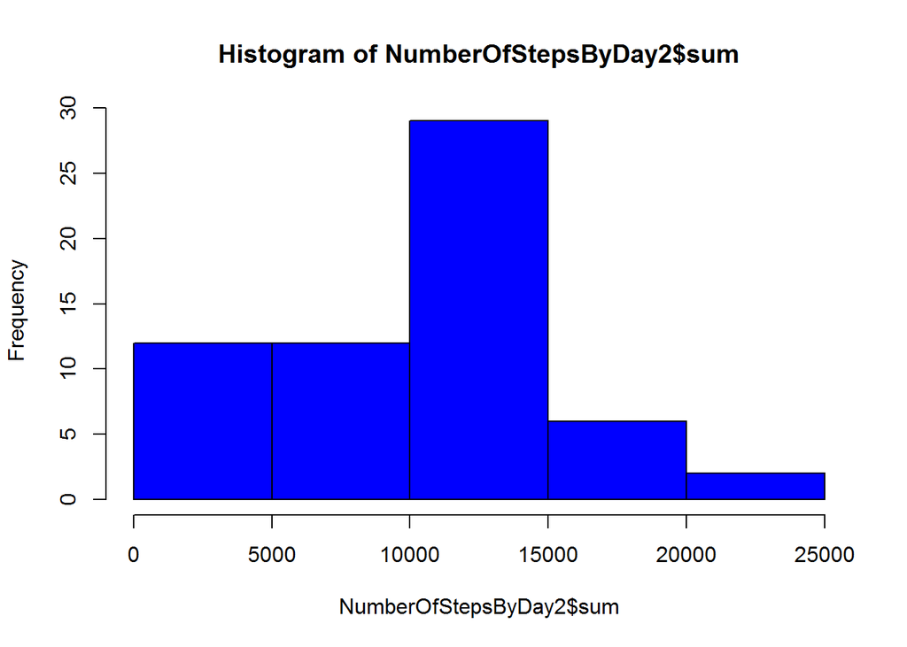

```r
NumberOfStepsByDay2 <- ddply(ActivityMonotoringData2,
                             .(ActivityMonotoringData2$date),
                             summarise, sum = sum(steps, na.rm = TRUE))

hist(NumberOfStepsByDay2$sum, col = "blue")
```

```r
mean(NumberOfStepsByDay2$sum)
```

```
## [1] 9530.724
```

```r
median(NumberOfStepsByDay2$sum)
```

```
## [1] 10439
```

### 5 - Are there differences in activity patterns between weekdays and weekends?

Create a new factor variable in the dataset with two levels – “weekday” and “weekend” indicating whether a given date is a weekday or weekend day.

i preferte use as.POSIXlt (and as.Date) Instead of weekdays because it return a integer 0 to 6 (sunday to saturday), easier to manipulate.

I create the new column

```r
ActivityMonotoringData2$typeDay <- "NA"
```

And i update the value :  
- 0,6 : it’s sunday and saturday -> weekend  
- 1 to 5 : monday to friday > weekday

```r
ActivityMonotoringData2$typeDay[
   which(as.POSIXlt(as.Date(ActivityMonotoringData2$date))$wday %in% c(0,6))
   ] <- "weekend"
ActivityMonotoringData2$typeDay[
   which(as.POSIXlt(as.Date(ActivityMonotoringData2$date))$wday %in% c(1,2,3,4,5))
   ] <- "weekday"
```

Make a panel plot containing a time series plot (i.e. type = “l”) of the 5-minute interval (x-axis) and the average number of steps taken, averaged across all weekday days or weekend days (y-axis).

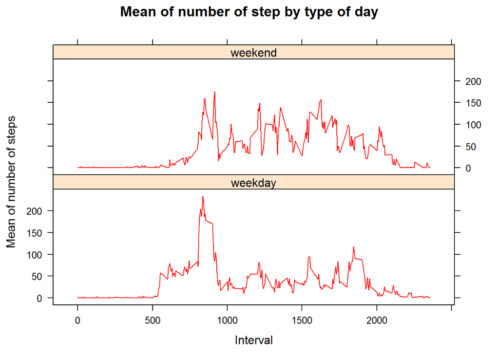

```r
library(lattice)
AverageStepsByInt2 <- ddply(ActivityMonotoringData2, .(interval,typeDay),
                           summarise, mean = mean(steps, na.rm = TRUE))

xyplot(  type = "l",
         data = AverageStepsByInt2,
         mean ~ interval | typeDay,
         main = "Mean of number of step by type of day",
         xlab = "Interval",
         ylab = "Mean of number of steps",
         layout = c(1,2),
         col.line = c("red")
)
```